# Praca domowa 2

Adam Bagiński

## Dane

Dane wykorzystane w Pracy domowej 2 dotyczą wyników egzaminów z 3 umiejętności: czytania, pisania i operacji matematycznych. Dodatkowo dostępne są podstawowe informacje o studentach i ich rodzicach. Opis wszystkich kolumn znajduje się również w pliku `README.md`.

| Zmienna | Opis |
| --- | --- |
| **gender** | płeć |
| **race.ethnicity** | pochodzenie etniczne |
| **parental.level.of.education** | wykształcenie rodziców |
| **lunch** | jaki obiad jedli uczniowie w dniu egzaminu |
| **test.preparation.course** | czy uczeń odbył kurs przygotowujący |
| **math.score** | wynik egzaminu z matematyki |
| **reading.score** | wynik egzaminu z czytania |
| **writing.score** | wynik egzaminu z pisania |

## Zadanie 1

Jak wyglądają rozkłady wyników uczniów z trzech przedmiotów (matematyka, czytanie, pisanie)?

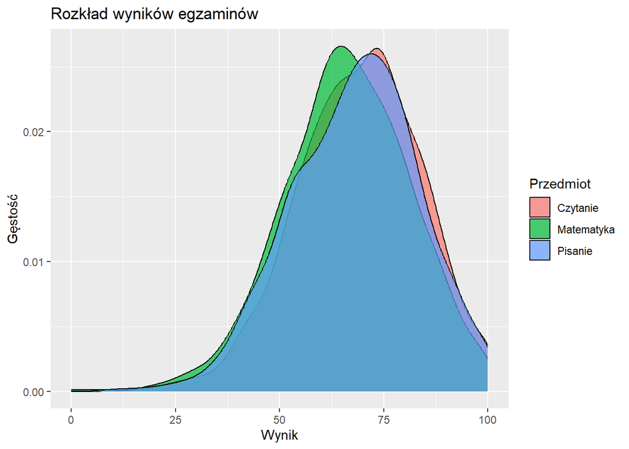

```r
df_l <- df %>%
  pivot_longer(c(math.score, reading.score, writing.score),
               names_to = "subject",
               values_to = "score")

df_l <- df_l %>%
  mutate(subject = case_when(
    subject == "math.score" ~ "Matematyka",
    subject == "reading.score" ~ "Czytanie",
    subject == "writing.score" ~ "Pisanie"),
    gender = case_when(
      gender == "female" ~ "Kobieta",
      gender == "male" ~ "Mężczyzna"),
    test.preparation.course = case_when(
      test.preparation.course == "completed" ~ "Tak",
      test.preparation.course == "none" ~ "Nie"))

ggplot(df_l, aes(x = score, fill = subject)) +
  geom_density(alpha = 0.7) +
  labs(title = "Rozkład wyników egzaminów",
       x = "Wynik",
       y = "Gęstość",
       fill = "Przedmiot")
```

**Komentarz: Rozkłady są do siebie bardzo zbliżone zarówno kształtem jak i wartościami. Rozkłady przypominają trochę rozkład normalny z większą niż 0 kurtozą. Wyróżnia się rozkład wyników z matematyki, który jest nieznacznie przesunięty w lewo oraz rozkład pisania - który jest przesunięty minimalnie w lewo dla niższych wartości.**

## Zadanie 2

Czy istnieje zauważalna różnica w wynikach między uczniami i uczennicami?

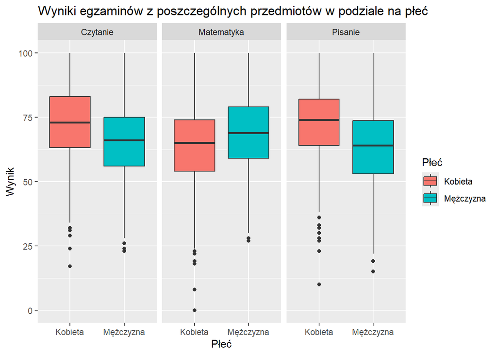

```r
ggplot(df_l, aes(x = gender, y = score, fill = gender)) +
  geom_boxplot() +
  facet_wrap(~subject) +
  labs(title = "Wyniki egzaminów z poszczególnych przedmiotów w podziale na płeć",
       x = "Płeć",
       y = "Wynik",
       fill = "Płeć")
```

**Komentarz: Istnieją zauważalne różnice w wynikach z poszczególnych w podziale na płeć, wykres implikuje też, że istnieje różnica w uśrednionych wynikach ze wszystkich egzaminów, ponieważ przewaga mężczyzn w matematyce jest mniejsza niż łączna przewaga kobiet w czytaniu i pisaniu. Największą względną jak i bezwzględną różnicę w wynikach widzimy w pisaniu - jest to rożnica na korzyść kobiet. Warto również odnotować większą ilość wyników odstających w przypadku kobiet.**

## Zadanie 3

Czy uczniowie, którzy ukończyli kurs przygotowawczy, osiągają lepsze wyniki niż pozostali?

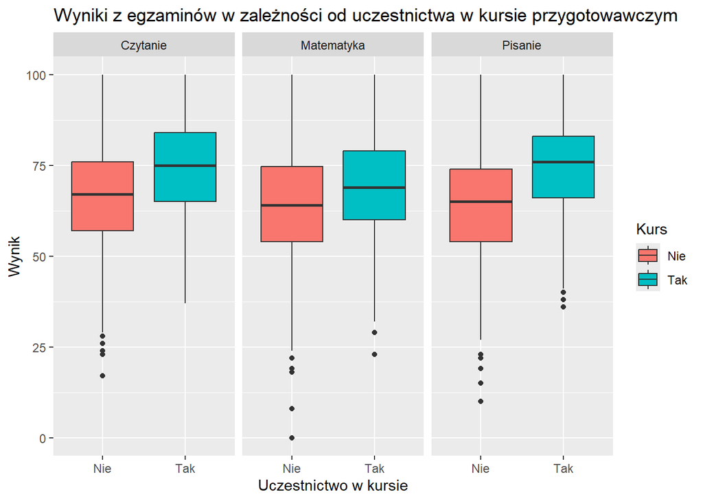

```r
ggplot(df_l, aes(x = test.preparation.course, y = score, fill = test.preparation.course)) +
  geom_boxplot() +
  facet_wrap(~subject) +
  labs(title = "Wyniki z egzaminów w zależności od uczestnictwa w kursie przygotowawczym",
       x = "Uczestnictwo w kursie",
       y = "Wynik",
       fill = "Kurs")
```

**Komentarz: Wykres jednoznacznie pokazuje, że uczniowie, którzy wzięli udział w kursie osiągają lepsze wyniki w egzaminach z każdego przedmiotu. Wg danych najlepszy efekt kurs osiąga w dziedzinie pisania. Dodatkowo, uczniowie po kursie odnotowują mniej obserwacji odstających.**

## Zadanie 4

Jaki jest związek między poziomem wykształcenia rodziców a średnimi wynikami uczniów?

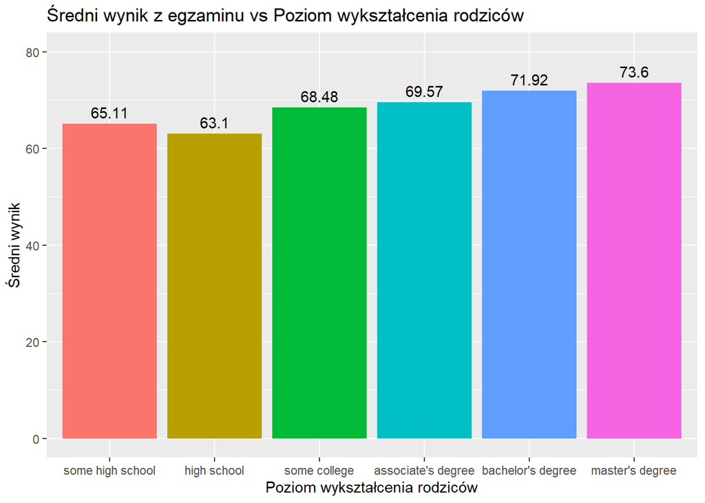

```r
df_l <- df_l %>%
  mutate(parental.level.of.education = factor(parental.level.of.education,
         levels = c("some high school", "high school", "some college",
                    "associate's degree", "bachelor's degree", "master's degree")))

df_l %>%
  group_by(parental.level.of.education) %>%
  summarise(mean_score = sum(score) / length(score)) %>%
  ggplot(aes(x = parental.level.of.education, y = mean_score,
         fill = parental.level.of.education)) +
  geom_col() +
  geom_text(aes(label = round(mean_score, 2)), vjust = -0.5) +
  scale_y_continuous(limits = c(0, 80)) +
  labs(title = "Średni wynik z egzaminu vs Poziom wykształcenia rodziców",
       x = "Poziom wykształcenia rodziców",
       y = "Średni wynik") +
  theme(legend.position = "none")
```

**Komentarz: Wykres jednoznacznie pokazuje rosnące średnie wyniki uczniów wraz z wyższym poziomem wykształcenia rodziców. Wyjątkiem od tej reguły jest poziom wykształcenia ‘high school’ oraz ‘some high school’, gdyż wynik dla uczniów z rodzicami z lepszym wykształceniem z tych dwóch jest gorszy.**

## Zadanie 5

Czy płeć i wykształcenie rodzica wpływa na wynik z matematyki?

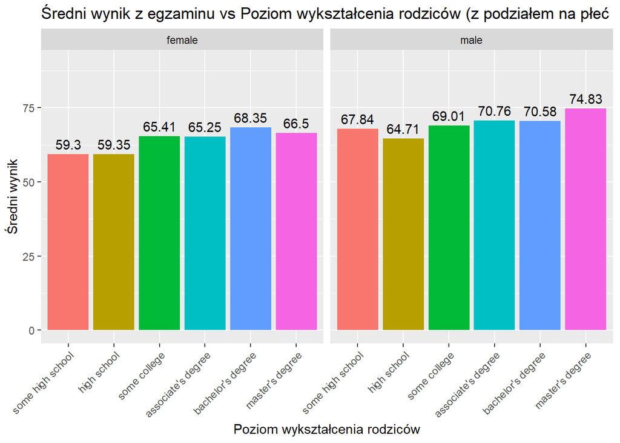

```r
df <- df %>%
  mutate(parental.level.of.education = factor(parental.level.of.education,
         levels = c("some high school", "high school", "some college",
                    "associate's degree", "bachelor's degree", "master's degree")))

df %>%
  group_by(parental.level.of.education, gender) %>%
  summarise(mat_score = sum(math.score) / length(math.score)) %>%
  ggplot(aes(x = parental.level.of.education, y = mat_score,
         fill = parental.level.of.education)) +
  geom_col() +
  geom_text(aes(label = round(mat_score, 2)), vjust = -0.5) +
  scale_y_continuous(limits = c(0, 90)) +
  facet_wrap(~gender) +
  labs(title = "Średni wynik z egzaminu vs Poziom wykształcenia rodziców (z podziałem na płeć",
       x = "Poziom wykształcenia rodziców",
       y = "Średni wynik") +
  theme(axis.text.x = element_text(angle = 45, hjust = 1),
        legend.position = "none")
```

**Komentarz: Poza paroma wyjątkami - generalnie widać dodatnią zależność między poziomem wykształcenia rodzica i wynikami egzaminu z matematyki uczniów i uczennic. Zdarzają się przypadki gdzie średni wynik spada czy też jest bardzo zbliżony w do poprzedniego wraz z wyższym poziomem wykształcenia rodziców, jednak trend, choć mniej widoczny niż na poprzednim wykresie, zostaje zachowany. Jak wcześniej wspomniano - mężczyźni osiągają w tym obszarze lepsze wyniki niż uczennice.**

## Zadanie 6

Czy istnieje zależność między wynikami z matematyki a wynikami z czytania lub pisania?

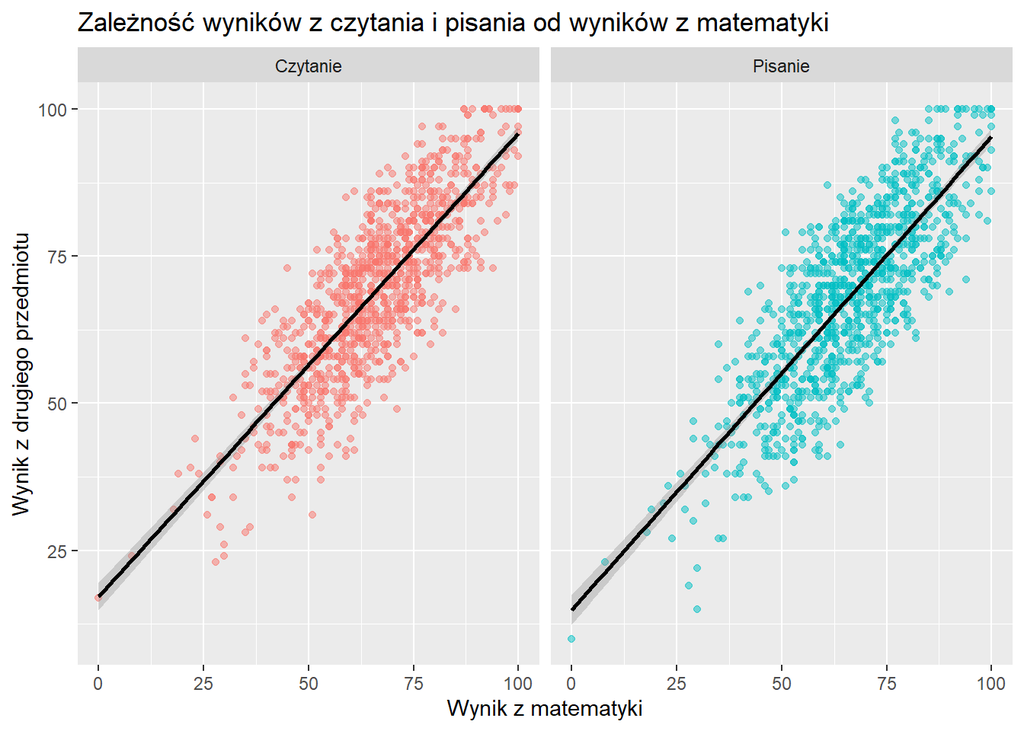

```r
df_l2 <- df %>%
  pivot_longer(cols = c(reading.score, writing.score),
               names_to = "subject",
               values_to = "score")

df_l2 <- df_l2 %>%
  mutate(subject = case_when(
    subject == "reading.score" ~ "Czytanie",
    subject == "writing.score" ~ "Pisanie"))

ggplot(df_l2, aes(x = math.score, y = score)) +
  geom_point(aes(color = subject), alpha = 0.5) +
  geom_smooth(method = "lm", color = "black") +
  facet_wrap(~subject) +
  labs(title = "Zależność wyników z czytania i pisania od wyników z matematyki",
       x = "Wynik z matematyki",
       y = "Wynik z drugiego przedmiotu") +
  theme(legend.position = "none")
```

**Komentarz: Z wykresów jasno wynika, że istnieje bardzo silna zależność między wynikami z matematyki, a wynikami z pozostałych przedmiotów. Im lepszy wynik z matematyki, tym lepszy wynik z czytania jak i pisania**